# Statistical Report of the SIA Mission 2024

Author

Affiliations

George A. Romero, MS

UNMSM | ADIECS | PAMS

Abstract

This report provides a comprehensive statistical summary of the patient data collected during the SIA Mission 2024. The analysis includes descriptive statistics, highlighting key demographic trends, health outcomes, and the prevalence of conditions observed among the participants. By presenting these findings, the report aims to offer valuable insights into the population served and to support future healthcare planning and interventions in similar missions.

Keywords

Descriptive statistics, SIA, PAMS

[figure not shown]

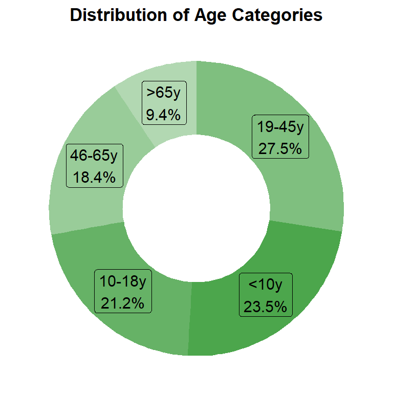

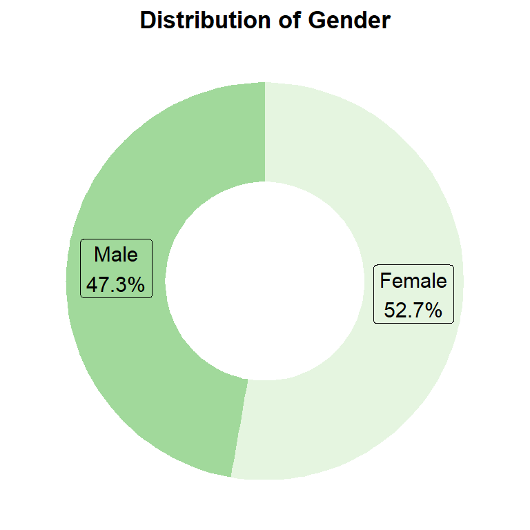

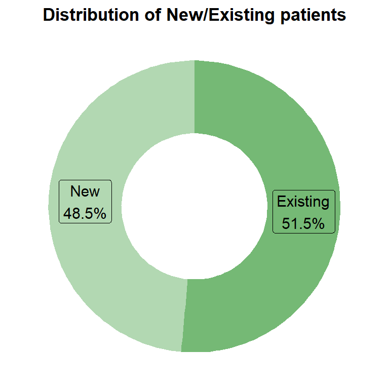

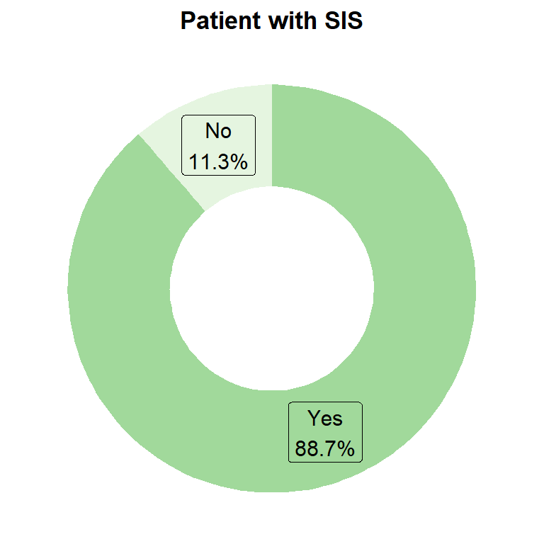

The following section presents the results of the descriptive analysis in the form of questions for better understanding and interpretation.

**What were the most common diagnoses in the mission?**

**General**

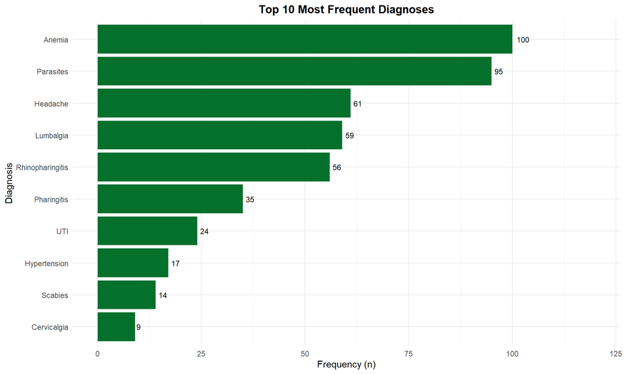

**By age**

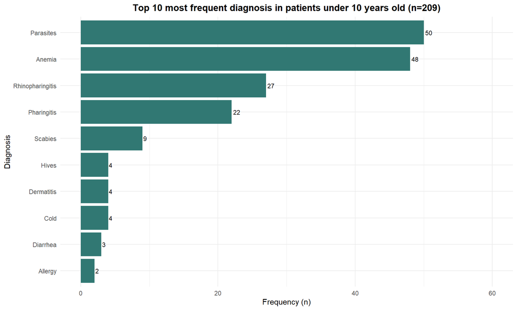

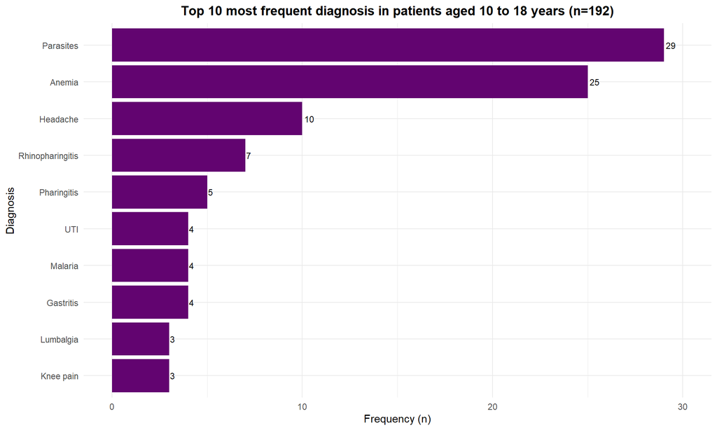

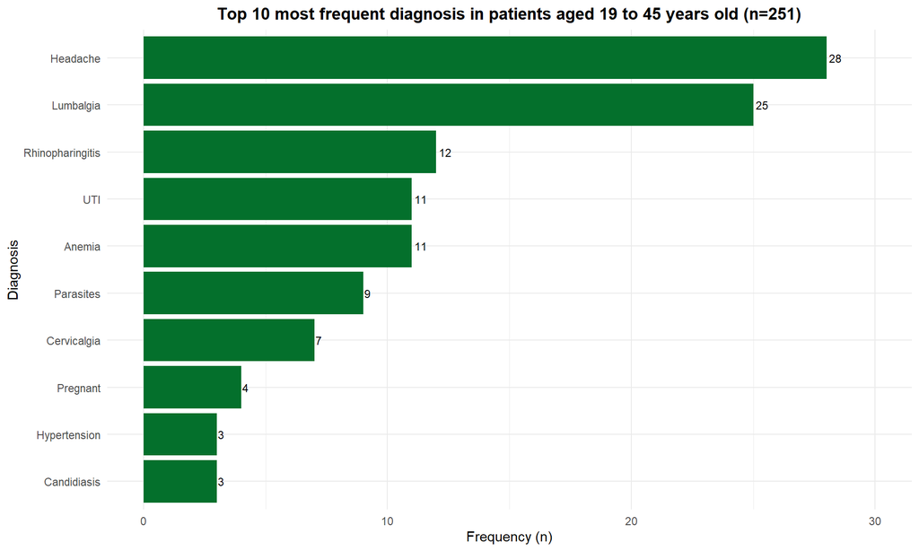

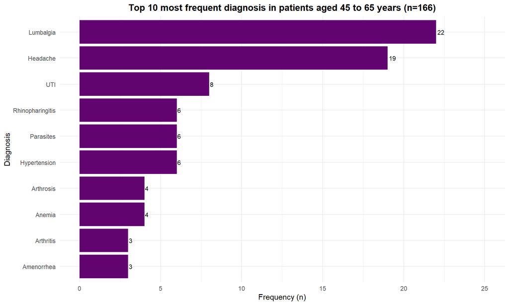

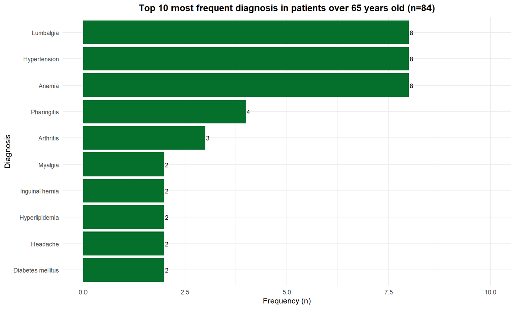

**By gender**

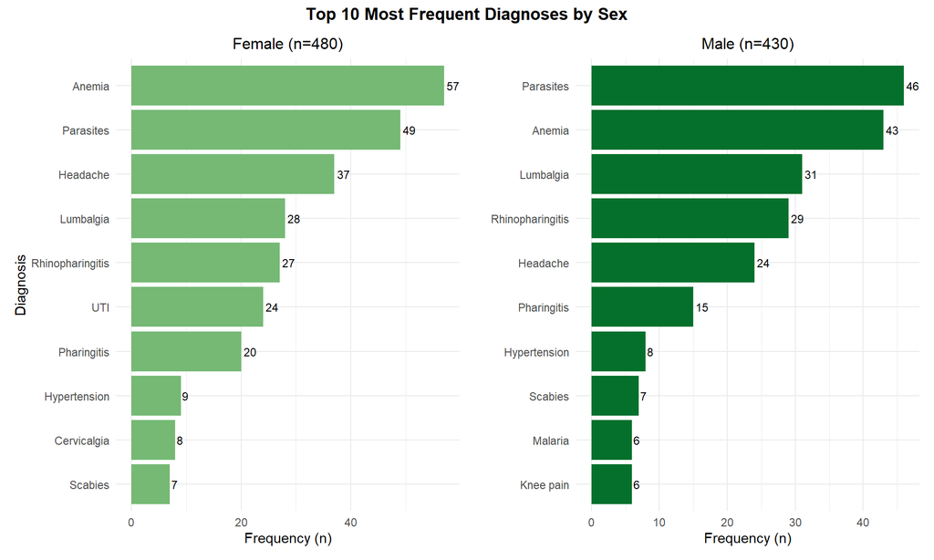

**What were the most prescribed medications?**

**General**

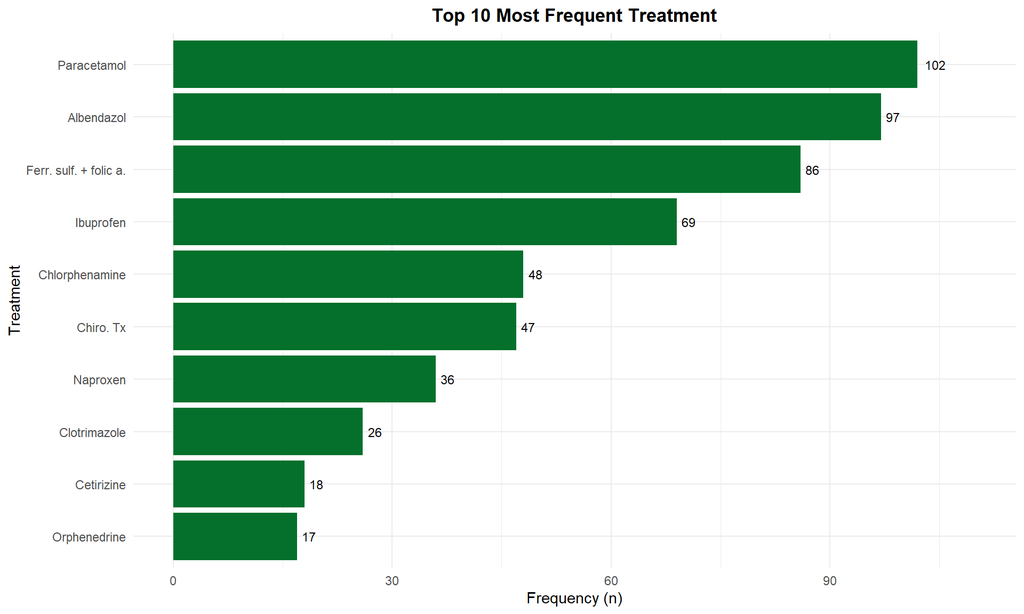

**By age**

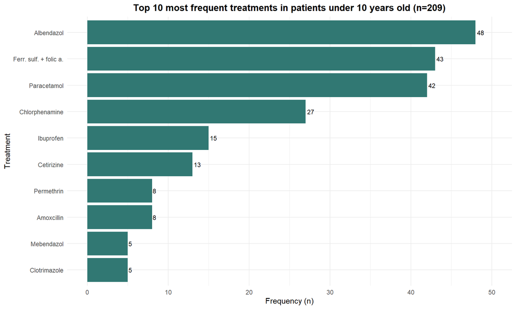

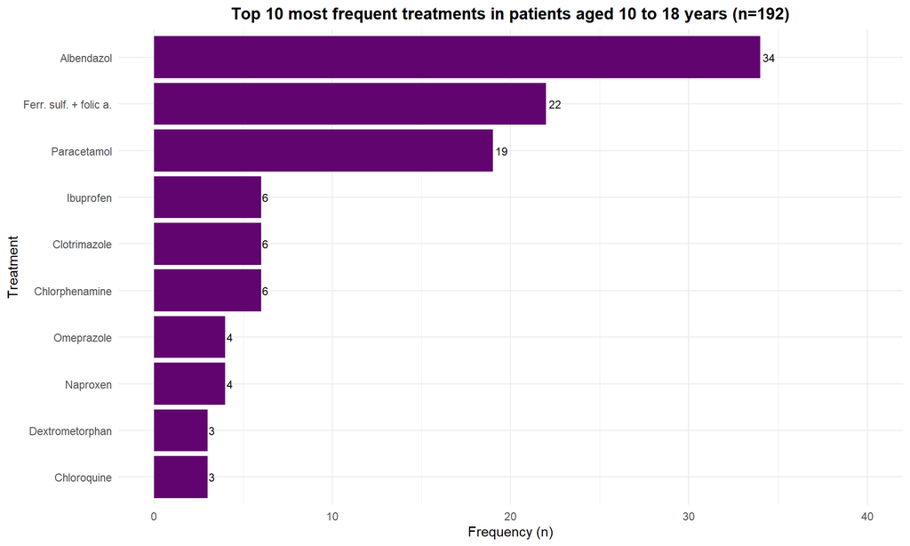

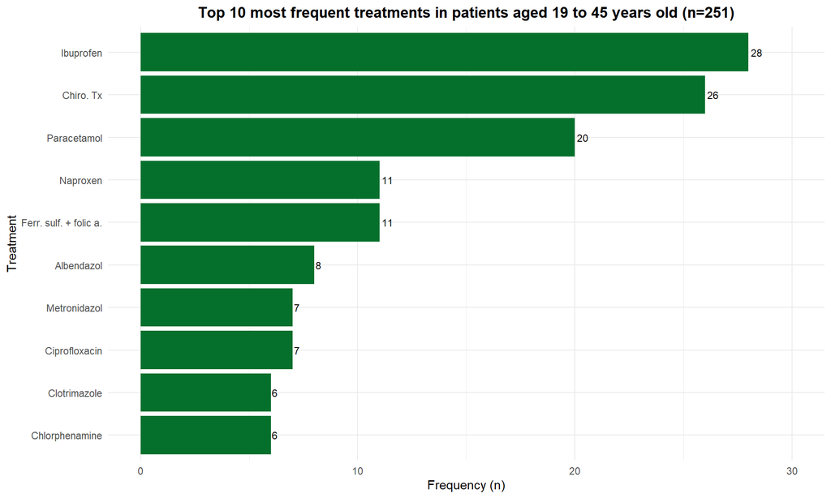

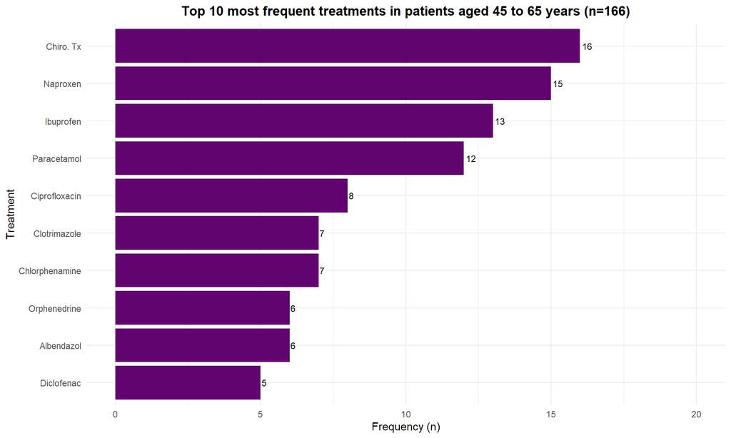

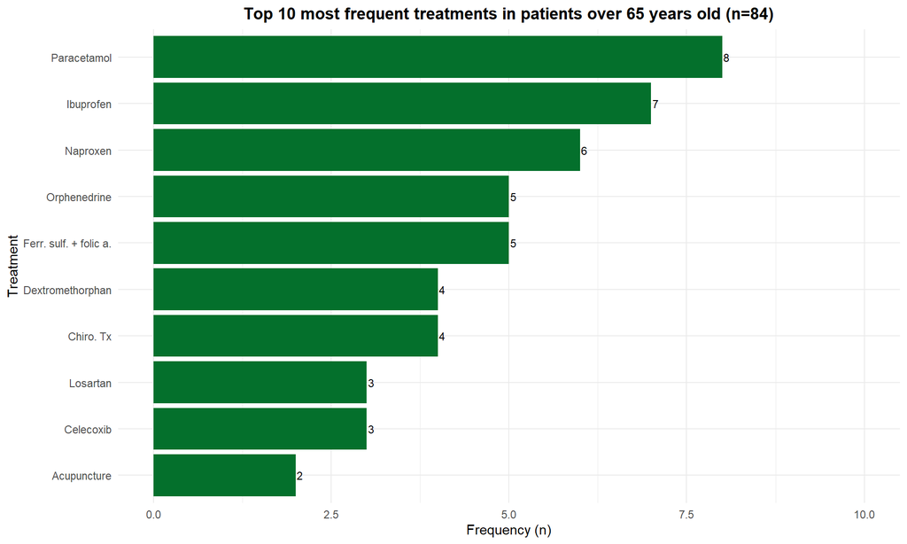

**By gender**

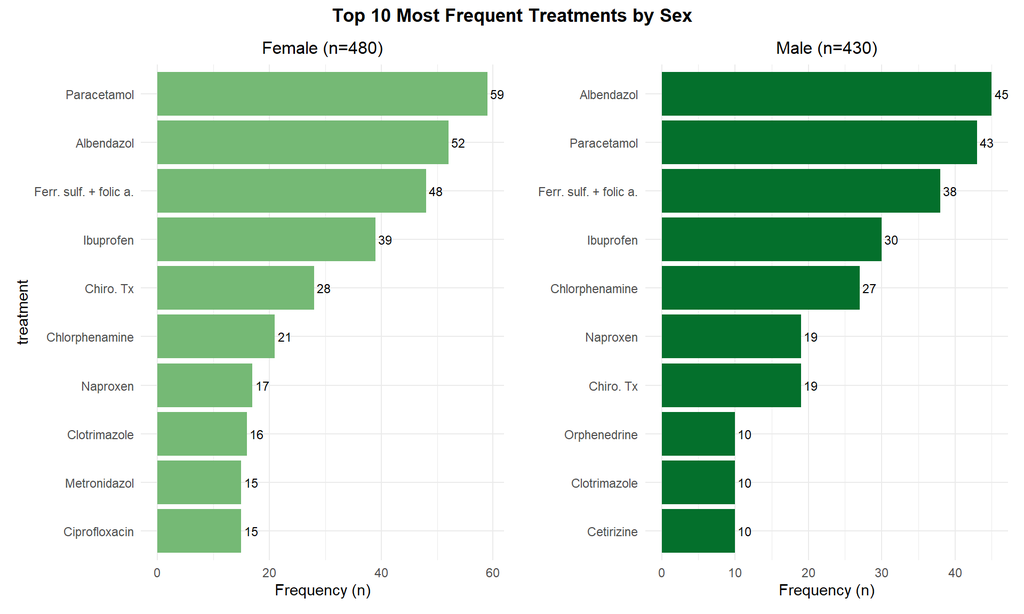

**What is the percentage of anemia in the population served?**

**General**

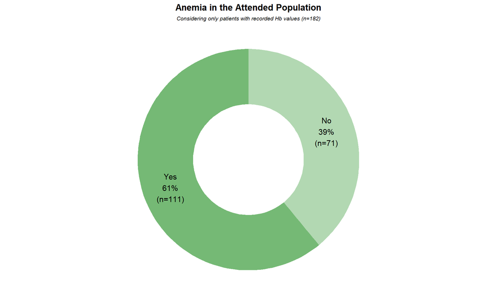

**By age**

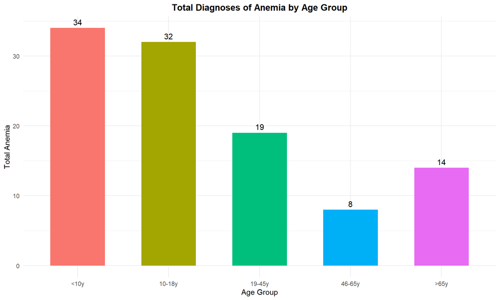

**By gender**

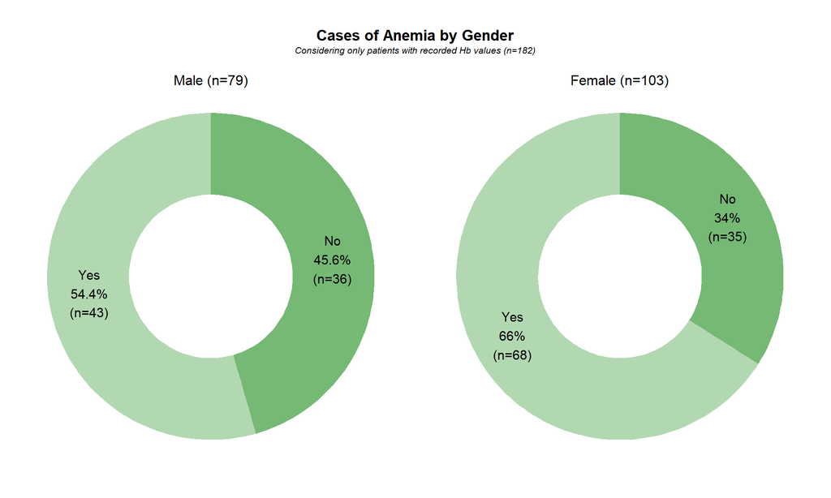

**By village**

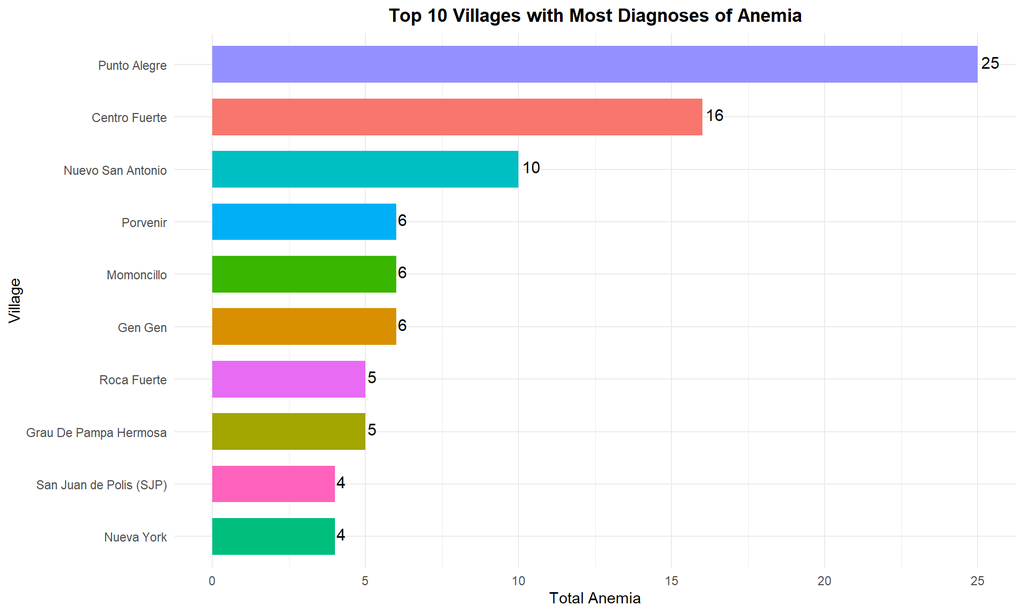

**How Many Patients Presented with Hypertension?**

**General**

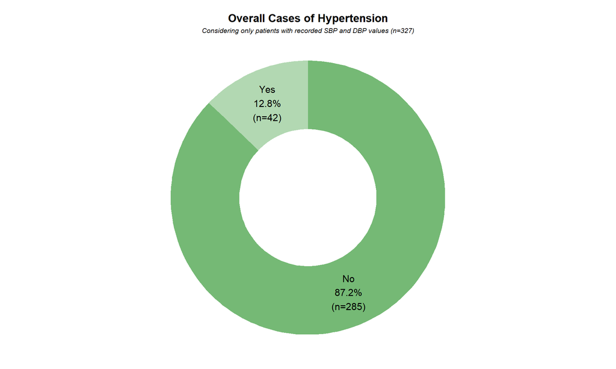

**By gender**

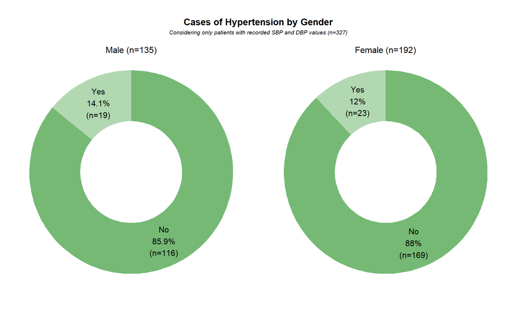

**How Many Patients Presented with Diabetes Mellitus?**

**General**

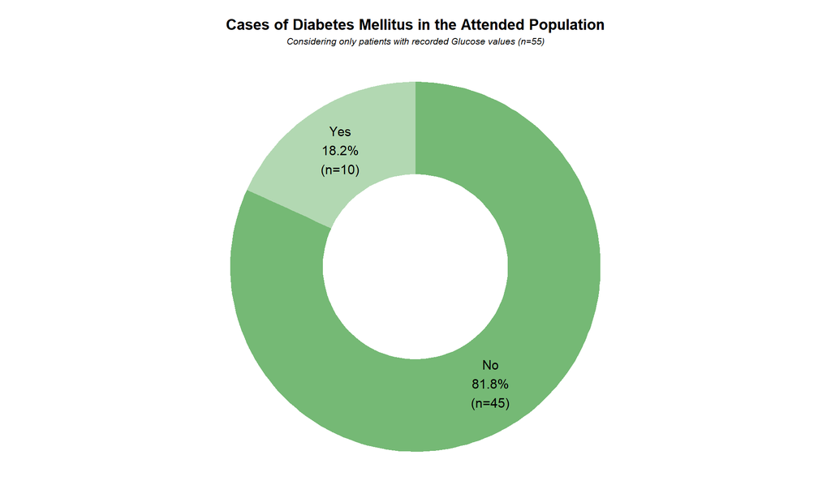

**By gender**

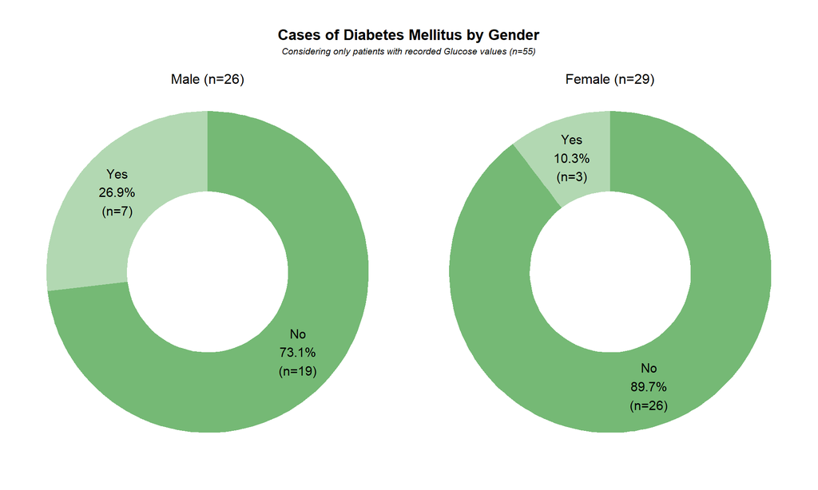

**How Many Patients Presented with High Cholesterol?**

**General**

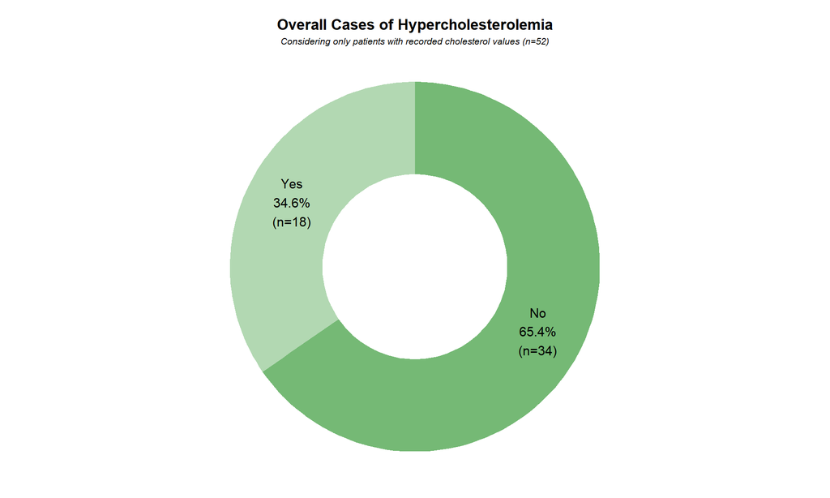

**By gender**

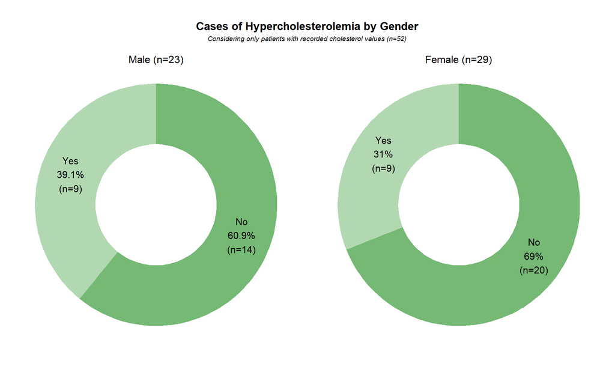

**How Many Patients Presented with High Triglycerides?**

**General**

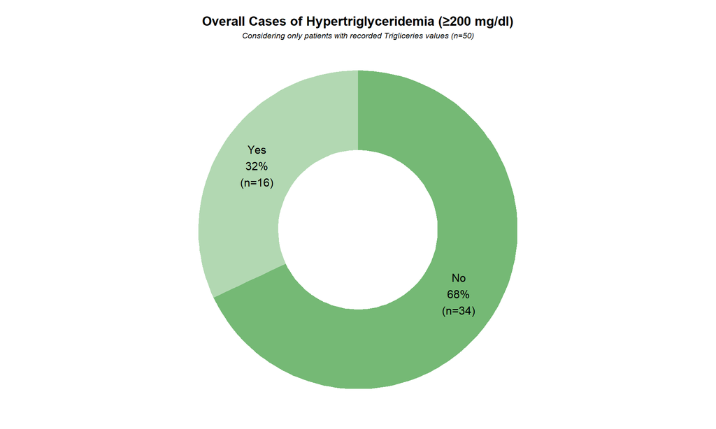

**By gender**

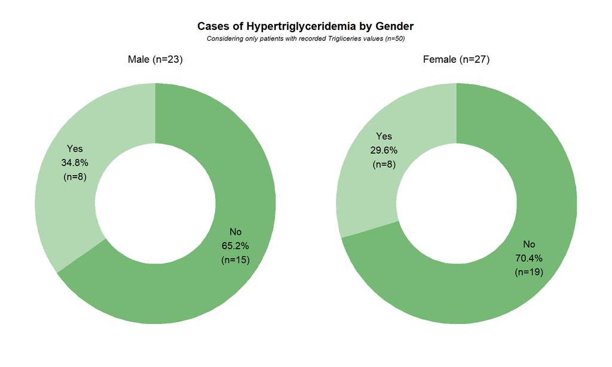

**Some lab values: Hemoglobin and Glucose values**

**General**

Hemoglobin and Glucose: Descriptive Statistics

| Lab | Mean | Median | Min | Max |
| --- | --- | --- | --- | --- |
| Hemoglobin | 11.99 | 11.95 | 5 | 17.1 |
| Glucose | 115.80 | 106.00 | 11 | 421.0 |

**By gender**

Descriptive Statistics of Hemoglobin and Glucose by Gender

| Gender | Lab | Mean | Median | Min | Max |
| --- | --- | --- | --- | --- | --- |
| Hemoglobin | Female | 11.76 | 11.8 | 5.0 | 15.1 |
| Hemoglobin | Male | 12.29 | 12.1 | 7.9 | 17.1 |
| Glucose | Female | 108.07 | 105.0 | 89.0 | 135.0 |
| Glucose | Male | 124.42 | 106.0 | 11.0 | 421.0 |

**By Age**

Descriptive Statistics of Hemoglobin and Glucose by Age Group

| Lab | Age Group | Mean | Median | Min | Max |
| --- | --- | --- | --- | --- | --- |
| Hemoglobin | <10y | 11.03 | 11.30 | 6.7 | 13.6 |
| Hemoglobin | 10-18y | 12.28 | 12.10 | 10.0 | 15.2 |
| Hemoglobin | 19-45y | 12.84 | 13.00 | 5.0 | 15.5 |
| Hemoglobin | 46-65y | 13.28 | 13.15 | 11.2 | 17.1 |
| Hemoglobin | >65y | 11.81 | 11.60 | 10.0 | 15.7 |
| Glucose | <10y | 120.00 | 120.00 | 120.0 | 120.0 |
| Glucose | 10-18y | 85.14 | 97.00 | 11.0 | 106.0 |
| Glucose | 19-45y | 123.78 | 108.00 | 90.0 | 421.0 |
| Glucose | 46-65y | 121.38 | 107.00 | 95.0 | 223.0 |
| Glucose | >65y | 111.64 | 109.00 | 90.0 | 155.0 |

**How Many Patients Were Attended by Community?**

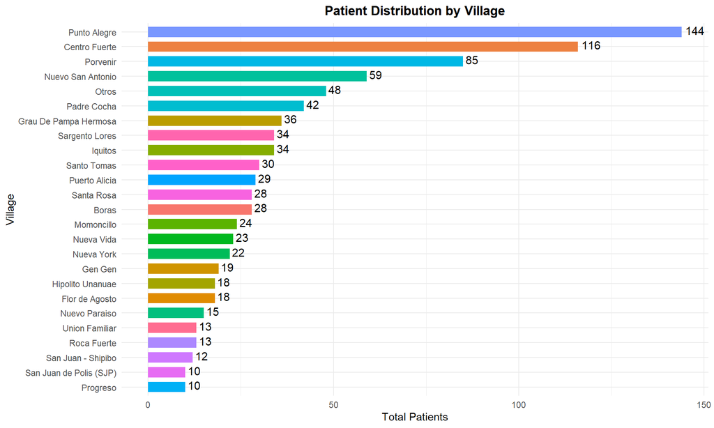